# Distributions

Interesting sources:

- https://www.edx.org/course/probability-the-science-of-uncertainty-and-data

```python
import numpy as np
import pandas as pd
```

# Uniform distribution

## Rolling a 6-sided die

[figure not shown]

```python
minValue = 1
maxValue = 6
numberOfSamples = 6 # Increase number to show that it converges to a uniform distribution
```

```python
results = pd.Series( np.random.randint(low=minValue, high=maxValue + 1, size=numberOfSamples) )
```

```python
results
```

```
0    5
1    6
2    2
3    2
4    6
5    3
dtype: int32
```

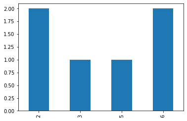

```python
results.value_counts().sort_index().plot(kind='bar')
```

## Normal distribution

### Sampling from the average length a full-grown citizen in the Netherlands.

```python
averageLength = 174.25
stdLength = 8
numberOfPeopleToSample = 3 # Play with these values to show the impact on the histogram
```

```python
randomLengths = pd.Series( np.random.normal(averageLength, stdLength, numberOfPeopleToSample) )
```

```python
randomLengths
```

```
0    179.186836
1    179.218754
2    178.345662
dtype: float64
```

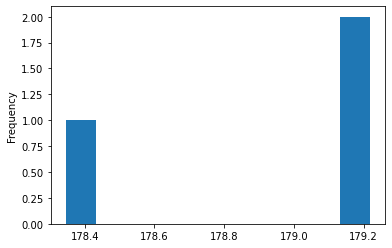

```python
randomLengths.plot(kind='hist', bins=10)
```

[figure not shown]

### Examples of normal distribution in real life

- https://studiousguy.com/real-life-examples-normal-distribution/
- https://galtonboard.com/probabilityexamplesinlife

### Central limit theorem

```python
sampleMeans = []
sampleSize = 100
sampleMeansSize = 10 # 10000

for i in range(sampleMeansSize):
    randomLengths = pd.Series( np.random.normal(averageLength, stdLength, sampleSize) )
    sampleMeans.append(randomLengths.mean())
```

```python
sampleMeans
```

```
[174.32904912033692,
 173.81206333352998,
 173.0551666169892,
 173.33177016094717,
 174.31953833465153,
 173.53053298677713,
 174.0778393775398,
 175.01068828177574,
 175.83577804352603,
 172.37414160189343]
```

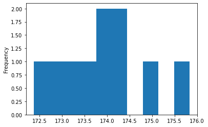

```python
pd.Series(sampleMeans).plot(kind='hist', bins = 10)
```

```python
sampleMeans = []
sampleSize = 100
sampleMeansSize = 10000

for i in range(sampleMeansSize):
    randomRolls = pd.Series( np.random.randint(low=minValue, high=maxValue + 1, size=sampleSize) )
    sampleMeans.append(randomRolls.mean())
```

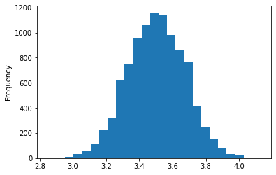

```python
pd.Series(sampleMeans).plot(kind='hist', bins = 25)
```

### Confidence interval

[figure not shown]

So let's reconsider one sample. Based on this one sample, what can we say about the mean of the underlying population?

```python
import scipy.stats as st
confidence = 0.95
st.t.interval(confidence, len(randomLengths)-1, loc=randomLengths.mean(), scale=st.sem(randomLengths))
```

```
(170.6702725413411, 174.07801066244576)
```

```python
import scipy.stats as st
confidence = 0.95
st.t.interval(confidence, len(randomRolls)-1, loc=randomRolls.mean(), scale=st.sem(randomRolls))
```

```
(3.1260847641601637, 3.8339152358398363)
```

Let's apply this to the iris dataset. What is the 95% confidence interval of the sepal_length? Meaning, let's calculate the interval that contains the real mean sepal length with 95% confidence.

```python
import seaborn as sns
iris = sns.load_dataset("iris")
iris.head()
```

|  | sepal_length | sepal_width | petal_length | petal_width | species |
| --- | --- | --- | --- | --- | --- |
| 0 | 5.1 | 3.5 | 1.4 | 0.2 | setosa |
| 1 | 4.9 | 3.0 | 1.4 | 0.2 | setosa |
| 2 | 4.7 | 3.2 | 1.3 | 0.2 | setosa |
| 3 | 4.6 | 3.1 | 1.5 | 0.2 | setosa |
| 4 | 5.0 | 3.6 | 1.4 | 0.2 | setosa |

```python
import scipy.stats as st
confidence = 0.95
st.t.interval(confidence, len(iris)-1, loc=iris['sepal_length'].mean(), scale=st.sem(iris['sepal_length']))
```

```
(5.709732481507366, 5.976934185159301)
```

### Portfolio assignment 7

15 min: Look at the histogram of at least 2 columns with numerical data in the dataset that you chose in portfolio assignment 4. Do you recognise the distribution? Does it look like a uniform or normal distribution or something else? If it doesn't look like a uniform or normal distribution, take a quick look here to see if you can find the distribution shape: https://www.itl.nist.gov/div898/handbook/eda/section3/eda366.htm

[figure not shown]

```python
imdb = pd.read_csv('..\imdb-data-2006-2016\IMDB-Movie-Data.csv')
imdb.head()
```

|  | Rank | Title | Genre | Description | Director | Actors | Year | Runtime (Minutes) | Rating | Votes | Revenue (Millions) | Metascore |
| --- | --- | --- | --- | --- | --- | --- | --- | --- | --- | --- | --- | --- |
| 0 | 1 | Guardians of the Galaxy | Action,Adventure,Sci-Fi | A group of intergalactic criminals are forced ... | James Gunn | Chris Pratt, Vin Diesel, Bradley Cooper, Zoe S... | 2014 | 121 | 8.1 | 757074 | 333.13 | 76.0 |
| 1 | 2 | Prometheus | Adventure,Mystery,Sci-Fi | Following clues to the origin of mankind, a te... | Ridley Scott | Noomi Rapace, Logan Marshall-Green, Michael Fa... | 2012 | 124 | 7.0 | 485820 | 126.46 | 65.0 |
| 2 | 3 | Split | Horror,Thriller | Three girls are kidnapped by a man with a diag... | M. Night Shyamalan | James McAvoy, Anya Taylor-Joy, Haley Lu Richar... | 2016 | 117 | 7.3 | 157606 | 138.12 | 62.0 |
| 3 | 4 | Sing | Animation,Comedy,Family | In a city of humanoid animals, a hustling thea... | Christophe Lourdelet | Matthew McConaughey,Reese Witherspoon, Seth Ma... | 2016 | 108 | 7.2 | 60545 | 270.32 | 59.0 |
| 4 | 5 | Suicide Squad | Action,Adventure,Fantasy | A secret government agency recruits some of th... | David Ayer | Will Smith, Jared Leto, Margot Robbie, Viola D... | 2016 | 123 | 6.2 | 393727 | 325.02 | 40.0 |

#### Left-Skewed Normal Distribution

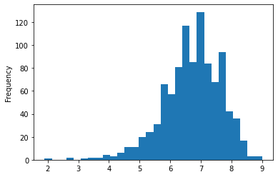

```python
imdb['Rating'].plot(kind='hist', bins=30)
```

#### Exponential distribution

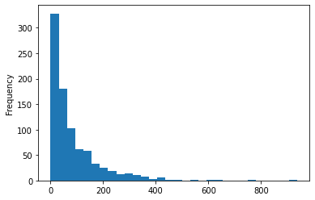

```python
imdb['Revenue (Millions)'].dropna().plot(kind='hist', bins=30)
```

### Portfolio assignment 8

15 min:

- Calculate the 90%, 95%, 99% and 99.99% confidence interval for at least 2 columns with numerical data in the dataset that you chose in portfolio assignment 4. Do you see the impact the confidence has on the interval?
- Now calculate the 95% confidence interval again but use only the first 10% of your rows. Compare this interval to the previous 95% confidence interval you calculated. Do you see the impact of having less data?

[figure not shown]

#### Increase in range with increasing confidence

```python
confArr = [.90, .95, .99, .9999]

print('Revenue')
for conf in confArr:
    print(f'confidence: {conf} - {st.t.interval(conf, len(imdb) - 1, loc=imdb["Revenue (Millions)"].dropna().mean(), scale=st.sem(imdb["Revenue (Millions)"].dropna()))}')

print('Rating')
for conf in confArr:
    print(f'confidence: {conf} - {st.t.interval(conf, len(imdb) - 1, loc=imdb["Rating"].dropna().mean(), scale=st.sem(imdb["Rating"].dropna()))}')
```

```
Revenue
confidence: 0.9 - (77.19963260369923, 88.71311968987874)
confidence: 0.95 - (76.094841042163, 89.81791125141497)
confidence: 0.99 - (73.93247628102071, 91.98027601255725)
confidence: 0.9999 - (69.29737551378523, 96.61537677979274)
Rating
confidence: 0.9 - (6.673978029510991, 6.772421970489008)
confidence: 0.95 - (6.664531713684794, 6.781868286315205)
confidence: 0.99 - (6.646042813899224, 6.800357186100775)
confidence: 0.9999 - (6.60641124242644, 6.8399887575735585)
```

#### Decrease in accuracy with smaller sample size

```python
imdbS = imdb.head(100)
print(f'confidence: .95 - {st.t.interval(.95, len(imdbS) - 1, loc=imdbS["Rating"].dropna().mean(), scale=st.sem(imdbS["Rating"].dropna()))}')
```

```
confidence: .95 - (6.874162000374451, 7.29783799962555)
```